# Capstone Project: Milestone

### dsscapstone-002

### November 2014

### Swiftkey/HC Corpora Dataset

#### Synopsis

The data for this project and the summary below comes from this source:  
https://d396qusza40orc.cloudfront.net/dsscapstone/dataset/Coursera-SwiftKey.zip

This file conatins large compilations of text from the “HC Corpora” corpus. This corpus is compiled from three sources and is available in four languages:

Sources: Blogs, News, Twitter  
Languages: English (en_US), German (de_DE), Russian (ru_RU), and Finnish (fi_FI)

For this project, we focused only on the English text documents.

#### Part 1: Data Preparation and Summary

Load necessary libraries and set options

```r
knitr::opts_chunk$set(echo=TRUE, fig.width=12, fig.height=4)

suppressMessages(library(tm))
suppressMessages(library(RWeka))
suppressMessages(library(ggplot2))
suppressMessages(library(qdap))
suppressMessages(library(scales))
suppressMessages(library(gridExtra))

options(scipen = 5)
options(warn = -1)
```

Read in the Text Files in the English Directory

```r
con <- file("final/en_US/en_US.blogs.txt", "r")
blogs <- readLines(con)
close(con)

con <- file("final/en_US/en_US.news.txt", "r")
news <- readLines(con)
close(con)

con <- file("final/en_US/en_US.twitter.txt", "r")
twitter <- readLines(con)
close(con)
```

Plot Line Counts of each Text Source (Blogs, News, Twitter)

```r
lengths <- c(length(blogs),length(news),length(twitter))
lengths <- data.frame(lengths)
lengths$names <- c("blogs","news","twitter")
```

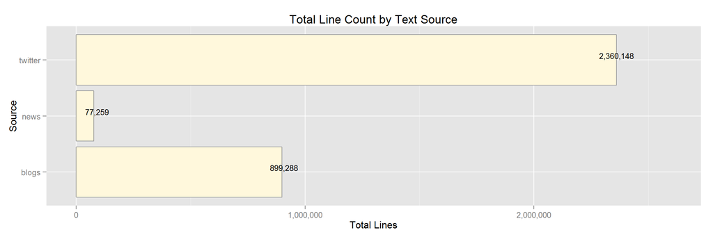

```r
ggplot(lengths,aes(x=names,y=lengths)) +
geom_bar(stat='identity',fill='cornsilk',color='grey60') + xlab('Source')+ylab('Total Lines') + coord_flip() + geom_text(aes(label=format(lengths,big.mark=","),size=3),labels=comma,vjust=-0.2)+scale_y_continuous(limits=c(0,2600000),labels=comma)+theme(legend.position='none') + ggtitle('Total Line Count by Text Source')
```

From the plot, we see that the total line counts are significantly different between the three text sources, and is dominated by “twitter”.

Next we examine the word counts. First we clean up the text files by

1. Erasing characters that are not alphabetic, spaces or apostrophes
2. Replacing multiple spaces with a single space, and trimming leading and trailing spaces
3. Change all text to lowercase

```r
blogs<- gsub("[^[:alpha:][:space:]']", " ", blogs)
blogs <- gsub("â ", "'", blogs)
blogs <- gsub("ã", "'", blogs)
blogs <- gsub("ð", "'", blogs)

news<- gsub("[^[:alpha:][:space:]']", " ", news)
news <- gsub("â ", "'", news)
news <- gsub("ã", "'", news)
news <- gsub("ð", "'", news)

twitter<- gsub("[^[:alpha:][:space:]']", " ", twitter)
twitter <- gsub("â ", "'", twitter)
twitter <- gsub("ã", "'", twitter)
twitter <- gsub("ð", "'", twitter)

blogs <- Trim(clean(blogs))
news <- Trim(clean(news))
twitter <- Trim(clean(twitter))

blogs <- tolower(blogs)
news <- tolower(news)
twitter <- tolower(twitter)
```

Now we count the number of words in each text sample using “lapply” with a function involving “strsplit”, and summarize the word counts for each text source with a barplot and histogram.

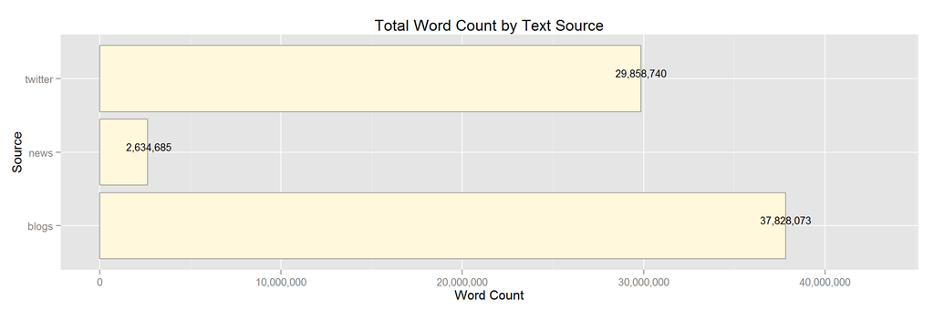

```r
## Blogs
word_count_blogs <- lapply(blogs, function (z) length(unlist(strsplit(z," "))))
word_count_blogs <- data.frame(do.call("rbind", word_count_blogs))
names(word_count_blogs) <- "Word Count"

## News
word_count_news <- lapply(news, function (z) length(unlist(strsplit(z," "))))
word_count_news <- data.frame(do.call("rbind", word_count_news))
names(word_count_news) <- "Word Count"

## Twitter
word_count_twitter <- lapply(twitter, function (z) length(unlist(strsplit(z," "))))
word_count_twitter <- data.frame(do.call("rbind", word_count_twitter))
names(word_count_twitter) <- "Word Count"

## Combine the three text sources together
word_counts <- c(sum(word_count_blogs),sum(word_count_news),sum(word_count_twitter))
word_counts <- data.frame(word_counts)
word_counts$names <- c("blogs","news","twitter")

## barplot of total word counts
ggplot(word_counts,aes(x=names,y=word_counts)) + geom_bar(stat='identity',fill='cornsilk',color='grey60')+ xlab('Source')+ylab('Word Count') + coord_flip() + geom_text(aes(label=format(word_counts,big.mark=","),size=3),labels=comma,vjust=-0.2)+scale_y_continuous(limits=c(0,43000000),labels=comma)+theme(legend.position='none')+ggtitle('Total Word Count by Text Source')
```

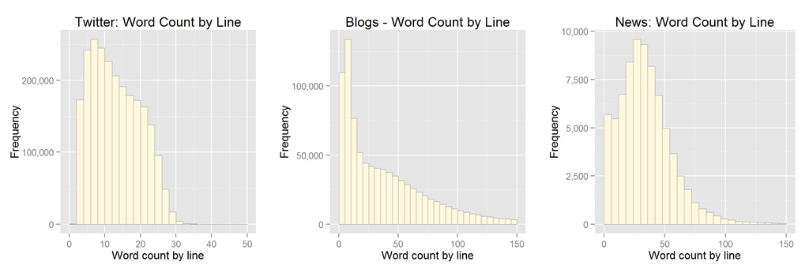

```r
## histogram of word counts for each text source
g1 <- ggplot(word_count_twitter, aes(x=word_count_twitter[,1])) +
geom_histogram(fill='cornsilk',color='grey60',size=.2, binwidth=2)+
xlim(0,50)+xlab('Word count by line')+ylab('Frequency') + scale_y_continuous(labels=comma)+ggtitle("Twitter: Word Count by Line")

g2 <- ggplot(word_count_blogs, aes(x=word_count_blogs[,1])) +
geom_histogram(fill='cornsilk',color='grey60',size=.2, binwidth=5)+
xlim(0,150)+xlab('Word count by line')+ylab('Frequency') + scale_y_continuous(labels=comma)+ggtitle("Blogs - Word Count by Line")

g3 <- ggplot(word_count_news, aes(x=word_count_news[,1])) +
geom_histogram(fill='cornsilk',color='grey60',size=.2, binwidth=6)+
xlim(0,150)+xlab('Word count by line')+ylab('Frequency') + scale_y_continuous(labels=comma)+ggtitle("News: Word Count by Line")

grid.arrange(g1,g2,g3, ncol=3)
```

```r
summary(word_count_twitter$'Word Count')
```

```
##    Min. 1st Qu.  Median    Mean 3rd Qu.    Max.
##    1.00    7.00   12.00   12.65   18.00   61.00
```

```r
summary(word_count_blogs$'Word Count')
```

```
##    Min. 1st Qu.  Median    Mean 3rd Qu.    Max.
##    0.00    9.00   29.00   42.06   60.00 6420.00
```

```r
summary(word_count_news$'Word Count')
```

```
##    Min. 1st Qu.  Median    Mean 3rd Qu.    Max.
##     0.0    19.0    31.0    34.1    45.0   640.0
```

From the barplots we see that “blogs” have the largest total word count, and “news” has the smallest. From the histograms, we see that the distribution of words per line is very different for the three text sources. “twitter” tends to have the fewest words per line. “blogs” has the most skewed distribution with a very long right tail. The distribution shape for “news” appears to be somewhere between the other two in terms of skewness.

From the summaries, we see that “blog” and “news” have a similar median number of words per line, while “twitter” has the smallest.

For our text prediction app we will eventually select a random sample from these three text sources. The samples will be chosen so that there is approximately the same number of words from each text source. This will ensure that the model is not biased towards one source of text.

#### Part 2: Common phrases in text files

Our predictive text model will eventually depend on a collection of phrases and their frequencies from our text sample. For this Milestone Report, we will list the most frequent phrases composed of one to three words in samples drawn from the text (1-grams through 3-grams). We remove some very common “stopwords” (e.g. “a”, “and”, “the”) from the sample before the analysis.

```r
# import a 10% subset of the text into a Corpus
set.seed(1111)

sample_blogs <- sample(blogs, length(blogs)/10)
sample_news <- sample(news, length(news)/10)
sample_twitter <- sample(twitter, length(twitter)/10)

sample_corpus <- Corpus(VectorSource(list(sample_blogs, sample_news, sample_twitter)))

sample_corpus <- tm_map(sample_corpus, removeWords, stopwords("english"))
```

```r
# define N-gram "tokenizer" function, to select 1-grams

Tokenizer <- function(x) NGramTokenizer(x, Weka_control(min = 1, max = 1))

# Create Document Term Matrix

one_gram_dtm <- TermDocumentMatrix(sample_corpus, control = list(tokenize = Tokenizer))
capture.output(one <- data.frame(inspect(one_gram_dtm))) -> .null
names(one) <- c("blogs","news","twitter")
one$Frequency <- rowSums(one)
one <- one[order(-one$Frequency),]
head(one)
```

```
##      blogs news twitter Frequency
## just 10122  413   15109     25644
## like 10017  377   12318     22712
## one  13140  723    8374     22237
## will 11265  857    9569     21691
## can  10804  464    9153     20421
## get   7135  361   11384     18880
```

```r
# define N-gram "tokenizer" function, to select 2-grams

Tokenizer <- function(x) NGramTokenizer(x, Weka_control(min = 2, max = 2))

# Create Document Term Matrix

two_gram_dtm <- TermDocumentMatrix(sample_corpus, control = list(tokenize = Tokenizer))
capture.output(two <- data.frame(inspect(two_gram_dtm))) -> .null
names(two) <- c("blogs","news","twitter")
two$Frequency <- rowSums(two)
two <- two[order(-two$Frequency),]
head(two)
```

```
##            blogs news twitter Frequency
## don t       2759   44     140      2943
## right now    513   42    1673      2228
## last night   317    9    1147      1473
## didn t      1314   19      18      1351
## feel like    462   16     695      1173
## m going      422   16     641      1079
```

```r
# define N-gram "tokenizer" function, to select 3-grams

Tokenizer <- function(x) NGramTokenizer(x, Weka_control(min = 3, max = 3))

# Create Document Term Matrix

three_gram_dtm <- TermDocumentMatrix(sample_corpus, control = list(tokenize = Tokenizer))
capture.output(three <- data.frame(inspect(three_gram_dtm))) -> .null
names(three) <- c("blogs","news","twitter")
three$Frequency <- rowSums(three)
three <- three[order(-three$Frequency),]
head(three)
```

```
##                blogs news twitter Frequency
## don t know       362    3      12       377
## mother s day      70    2     296       368
## let us know       27    0     191       218
## don t want       179    3       7       189
## happy new year    25    0     156       181
## m pretty sure     65    2     109       176
```

The table summaries above show the most frequent terms in the text sample, broken down by “blogs”, “news”, and “twitter”. Some very common single words are “just” and “like”, common 2-word phrases include “right now” and “last night”, and common 3-word phrases include “let us know” and “happy new year”.

#### Part 3: Predictive Text Model Algorithm

Here we discuss our plan for building an algorithm for predicting text. Since we have to consider the size and speed of our model, we will focus on 1-grams through 4-grams for the model for now. As we learn more about text-mining and language-modeling, our algorithm will probably change.

After checking that the user inputs a valid phrase (i.e. 2 words or more, text only) and cleaning up their input (i.e. alphabet characters only, lowercase, punctuation) we plan to use this algorithm:

1. If the input phrase is 2 words, choose the most frequent phrase from among 3-word phrases that start with the input phrase. The predicted word is the last word of the chosen 3-word phrase.
2. If the input phrase is 3 words, choose the most frequent phrase from among 4-word phrases that start with the input phrase. The predicted word is the last word of the chosen 4-word phrase.
3. If the input phrase is longer than 3 words, use only the last 3 input words and follow the procedure for a 3-word phrase.
4. If there is no prediction for a 3-word input phrase, use only the last 2 input words and follow the procedure for a 2-word phrase.
5. If there is no prediction for a 2-word input phrase, select the most frequent word in the text sample.

Example: user input = “we had a”

most frequent phrase beginning with user input = “we had a great”

predicted word = “great”

Other considerations:

- removing other common words and profanity
- using word “stems” to reduce size of the Document Term Matrix